# Statistical Inference Part 2

Armin Wallrab

Mai 2015

# Statistical Inference

## Part 2: Analysis of the ToothGrowth data

The ToothGrowth data set documents the effect of Vitamin C on tooth growth in guinea pigs.

Source C. I. Bliss (1952) The Statistics of Bioassay. Academic Press.

### 1. Load the ToothGrowth data and perform some basic exploratory data analyses

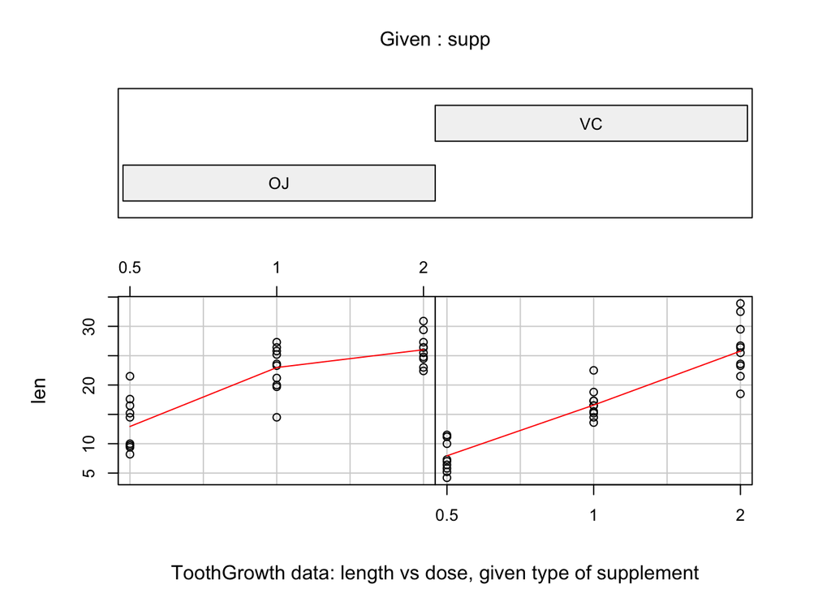

```r
library(datasets)
library(ggplot2)

data(ToothGrowth)
t <-ToothGrowth
t$dose <- as.factor(t$dose)

coplot(len ~ dose | supp, data = t, panel = panel.smooth, xlab="ToothGrowth data: length vs dose, given type of supplement")
```

The figure seems to show that dose has a direct influence on tooth growth. Orange juice (OJ) in lower doses also seems to have more effect than ascorbic acid (VC).

Let’s examine this in the sections below.

### 2. Provide a basic summary of the data

According to the help page, the data contains the length of odontoblasts (teeth) in each of 10 guinea pigs at each of three dose levels of Vitamin C (0.5, 1, and 2 mg) with each of two delivery methods (orange juice or ascorbic acid).

The data frame has 60 observations on 3 variables

- [,1] len numeric Tooth length
- [,2] supp factor Supplement type (VC or OJ).
- [,3] dose numeric Dose in milligrams.

```r
summary(t)
```

```
##       len        supp     dose
##  Min.   : 4.20   OJ:30   0.5:20
##  1st Qu.:13.07   VC:30   1  :20
##  Median :19.25           2  :20
##  Mean   :18.81
##  3rd Qu.:25.27
##  Max.   :33.90
```

```r
str(t)
```

```
## 'data.frame':    60 obs. of  3 variables:
##  $ len : num  4.2 11.5 7.3 5.8 6.4 10 11.2 11.2 5.2 7 ...
##  $ supp: Factor w/ 2 levels "OJ","VC": 2 2 2 2 2 2 2 2 2 2 ...
##  $ dose: Factor w/ 3 levels "0.5","1","2": 1 1 1 1 1 1 1 1 1 1 ...
```

```r
head(t)
```

```
##    len supp dose
## 1  4.2   VC  0.5
## 2 11.5   VC  0.5
## 3  7.3   VC  0.5
## 4  5.8   VC  0.5
## 5  6.4   VC  0.5
## 6 10.0   VC  0.5
```

### 3. Use confidence intervals and/or hypothesis tests to compare tooth growth by supp and dose

At first sight the distributions of tooth length by delivery method and dose levels, seem to indicate that for 0.5 and 1 mg, the mean tooth length is greater for those treated with orange juice. For the 2 mg dose the mean increase seems to be independent of the type of dose.

Let’s verify with confidence interval testing.

I’ll subset appropriately and utilize t.test() to determine each scenarios confidence interval, subset means, and p-value.

#### Supplement only

```r
s1 <- subset(t, supp=="VC")$len
s2 <- subset(t, supp=="OJ")$len
d <- t.test(s1, s2, paired=FALSE, var.equal=FALSE)
d$p.value
```

```
## [1] 0.06063451
```

```r
d$conf.int[1:2]
```

```
## [1] -7.5710156  0.1710156
```

The p-value is 0.06 and the confidence interval contains 0. I don’t reject the null hypothesis, i.e. type of supplement alone does not affect tooth growth.

#### Dose only

```r
s1 <- subset(t, dose=="0.5")$len
s2 <- subset(t, dose=="1")$len
d <- t.test(s1, s2, paired=FALSE, var.equal=FALSE)
d$conf.int[1:2]
```

```
## [1] -11.983781  -6.276219
```

If I increase dose from 0.5 to 1.0 milligrams, the confidence interval doesn’t contain 0. I can reject the null hypothesis that this increase doesn’t increase tooth length.

```r
s1 <- subset(t, dose=="1")$len
s2 <- subset(t, dose=="2")$len
d <- t.test(s1, s2, paired=FALSE, var.equal=FALSE)
d$conf.int[1:2]
```

```
## [1] -8.996481 -3.733519
```

Similar result for increase from 1.0 to 2.0.

I.e. an increased dose definitely leads to an increased length.

#### Supplement by dose

```r
s1 <- subset(t, supp=="VC" & dose=="0.5")$len
s2 <- subset(t, supp=="OJ" & dose=="0.5")$len
d <- t.test(s1, s2, paired=FALSE, var.equal=FALSE)
d$conf.int[1:2]
```

```
## [1] -8.780943 -1.719057
```

The confidence interval doens’t contain 0, thus I reject the null hypothesis that supplement type with a 0.5 dose doesn’t affect tooth growth.

```r
s1 <- subset(t, supp=="VC" & dose=="1")$len
s2 <- subset(t, supp=="OJ" & dose=="1")$len
d <- t.test(s1, s2, paired=FALSE, var.equal=FALSE)
d$conf.int[1:2]
```

```
## [1] -9.057852 -2.802148
```

Same result fro 1.0 dose.

```r
s1 <- subset(t, supp=="VC" & dose=="2")$len
s2 <- subset(t, supp=="OJ" & dose=="2")$len
d <- t.test(s1, s2, paired=FALSE, var.equal=FALSE)
d$p.value
```

```
## [1] 0.9638516
```

```r
d$conf.int[1:2]
```

```
## [1] -3.63807  3.79807
```

The confidence interval contains 0 and the p-value is close to 1.0. Thus I don’t reject the null hypothesis that supplement type with a 2.0 dose doesn’t affect tooth growth.

I.e. I can’t conclude which supplement has a bigger affect on tooth growth for 2.0.

### 4. State your conclusions and the assumptions needed for your conclusions

Conclusions

- With increase in dose, the tooth length increases as well
- Independent of dose size, supplement type alone doesn’t affect tooth growth
- Orange Juice has more effect then Ascorbic Acid with a 0.5 and 1.0 dose size
- There’s no difference between Orange Juice and Ascorbic Acid for 2.0 doses

The following assumptions were made:

- The samples are independent
- The distribution is normal